# Project Part 3

Group 13

2024-11-23

# Project Part 3 - Classification

In previous reports, we analyzed COVID-19 datasets to identify key insights enabling Texas policymakers to mitigate the impact of future pandemics. We thoroughly examined and visualized key relationships between our feature sets and confirmed COVID-19 cases and deaths, identifying clusters of vulnerable demographics in need of support, such as:

- Older communities at increased risk of death
- Impoverished communities in need of financial systems to reduce the infection rates

In this report, we expand on these insights by training classification models to predict infection and death rates among Texas communities. Our goal is to enable Texas policymakers to respond rapidly to emerging threats through preemptive analysis built on a robust statistical foundation.

We will begin, in Section 1, by training Logistic Regression, Support Vector Machine, and Artificial Neural Network classifiers to identify Texas counties at high risk of death. These classifiers will help policymakers optimize healthcare resource allocation, bolstering vulnerable healthcare systems and enabling healthcare workers to save lives.

In section 2 we look at the effectiveness of social distancing, and whether measures taken by counties can be used to predict an increase in the number of covid cases. We use the Naive Bayes, Random Forest, XGBoost, and Elastic Net classifiers to see if counties that decreased their mobility to a greater extent experienced a lower growth of covid. This can be used to help policymakers determine the appropriate level of social distancing to be recommended or required.

In Section 3, we examine the potential of demographic features of Texas counties to predict the risk of infection. We will use Random Forest, Artificial Neural Network, and a Support Vector Machine to classify these counties using the demographic features. They can be used by the policymakers to efficiently identify the areas that would be at risk of infection and provide medical support for these counties to minimize infection rates.

## 1. Evaluating Risk of Death

This section expands on previous analysis by training several classification models to categorize Texas counties based on the likelihood that their communities are susceptible to high death rates. Counties will be classified into two reasonably distributed groups, **Low Risk** and **High Risk**, enabling policymakers to focus resources on the most vulnerable areas and prepare to save lives during future pandemics.

We’ll begin the analysis by discussing preprocessing techniques to prepare the dataset for analysis, as well as how the features used in our classification model are selected. Next, we will analyze the predictive performance of our classification models and compare their effectiveness at classifying new and future datasets. Finally, we’ll conclude the section with key findings and recommendations on how the models can be used to inform resource allocation and save lives.

### 1.0 Class Label Selection

First, the dataset must be split into the two classes: **Low Risk** and **High Risk**. The feature `deaths_per_100_000` represents the number of COVID-19 related deaths in a Texas county at the time our dataset was collected. We can analyze this feature’s statistical distribution with a box-plot and determine a threshold by which to partition our dataset.

**Variable type: numeric**

| skim_variable | n_missing | complete_rate | mean | sd | p0 | p25 | p50 | p75 | p100 | hist |
| --- | --- | --- | --- | --- | --- | --- | --- | --- | --- | --- |
| deaths_per_100_000 | 0 | 1 | 185.52 | 98.91 | 0 | 119.91 | 172.73 | 239.36 | 628.37 | ▅▇▃▁▁ |

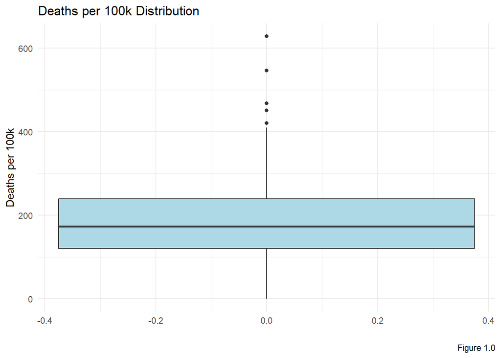

The statistical distribution of `deaths_per_100_000` in Figure 1.0 is **balanced** and contains a few outlier that represent counties with abnormally high death rates. Because the distribution is balanced, we can use the mean of **185.52** to split the dataset evenly between the classes. Counties with a `deaths_per_100_000` $\ge 185.52$ will be classified as **High Risk** and counties with `deaths_per_100_000` $\lt 185.52$ will be classified as **Low Risk**.

| Class | Description |
| --- | --- |
| Low Risk | Populations with < 185.52 deaths per 100,000 residents |
| High Risk | Populations with death $\ge$ 185.52 deaths 100,000 residents |

By splitting the dataset evenly between our classes we ensure that enough counties are labeled High Risk to be actionable for policymakers. There is no material harm in incorrectly labeling a county as High Risk beyond suboptimal government spending. Conversely, labeling mislabeling a county as Low Risk means residents’ may not receive adequate health resources and die unnecessarily.

Now that we understand how to split the dataset, we will proceed to clean the dataset in preparation for classification.

### 1.1 Data Preparation

In this portion of the analysis, we will prepare our dataset for classification. The performance of our classifiers heavily depend on the structure of data provided. We should remediate any missing or redundant values and eliminate any features that are not strong predictors from the dataset.

Our dataset currently contains 254 records with 259 features that represent census data of Texas counties from 2021.

Of these features, 10 do not contain data and should be removed. These features do not represent useful information and cannot be filled in with imputation.

Four features contain duplicate data (eg. all values in the column are identical) and should be removed. These features may negatively affect the classifiers’ performance by injecting bias.

Three features contain values that describe uniqueness, such as `county_name` and should be removed. These fields may negatively affect the classifiers’ performance by injecting unnecessary variance. This issue is known as the Curse of Dimensionality.

Next, we should ensure that only features with strong predictive traits are used. Features with no correlation to our class label may introduce too much variance, whereas features with too much correlation to one another may inject bias. In either case our model will not be able to accurately classify our records.

We can start isolating the predictive features using calculating the Pearson correlation coefficient for all features against the class label. A positive or negative correlation of $\ge 0.3$ indicates a strong linear relationship to the class label. This threshold is commonly used in statistical analysis to identify meaningful correlations and exclude weaker relationships that may not improve classification performance. These features should be kept in the dataset.

The following features have a strong correlation to the `risk_of_death` class label:

| Field Name | Correlation |
| --- | --- |
| `median_year_structure_built` | -0.48 |
| `median_rent` | -0.43 |
| `renter_occupied_housing_units_paying_cash_median_gross_rent` | -0.43 |
| `median_income` | -0.34 |
| `income_per_capita` | -0.34 |
| `confirmed_cases_per_100_000` | 0.32 |

The `confirmed_cases_per_100_000` is directly related to the `deaths_per_100_000` feature from which the class label was built. We will leave this feature intact, in order to allow policymakers to forecast death risk relative to the infectiousness of the future pandemic.

Next, we should ensure these features are not highly correlated with one another. As mentioned previously, redundant features may introduce bias into our classification models. There are two combinations of features we will need to analyze for redundancy:

- `median_income` and `income_per_capita`
- `median_rent` and `renter_occupied_housing_units_paying_cash_median_gross_rent`

Both feature combinations have very similar correlation coefficients and represent related attributes of our data. However, this does not necessarily mean they are redundant. For example, a low `median_income` with a high `income_per_capita` may indicate a level of income inequality that could be useful information for our classifiers.

We can evaluate these features for potential redundancy by calculating their Pearson correlation coefficient with one another and visualizing their distributions. A high correlation, or substantial overlap between distributions, could indicate redundancy.

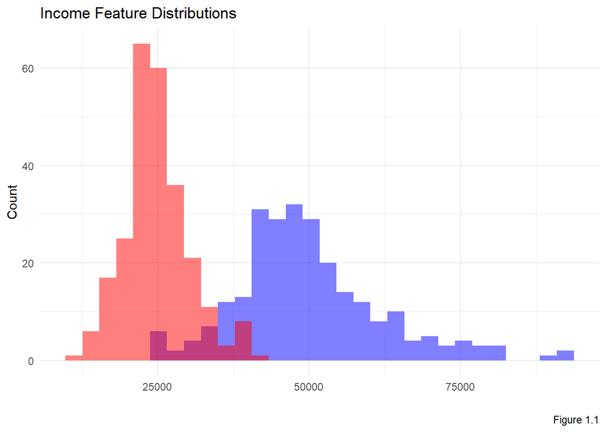

The features `median_income` and `income_per_capita` have a high positive correlation of **0.831** but their distributions (see Figure 1.1) do not contain substantial overlap. This indicates that these features likely represent separate but related attributes of the data. As such, we will retain both features in the dataset and evaluate our model’s performance using one or both features in a future analysis.

Next, we repeat the correlation analysis for the features `median_rent` to `renter_occupied_housing_units_paying_cash_median_gross_rent`.

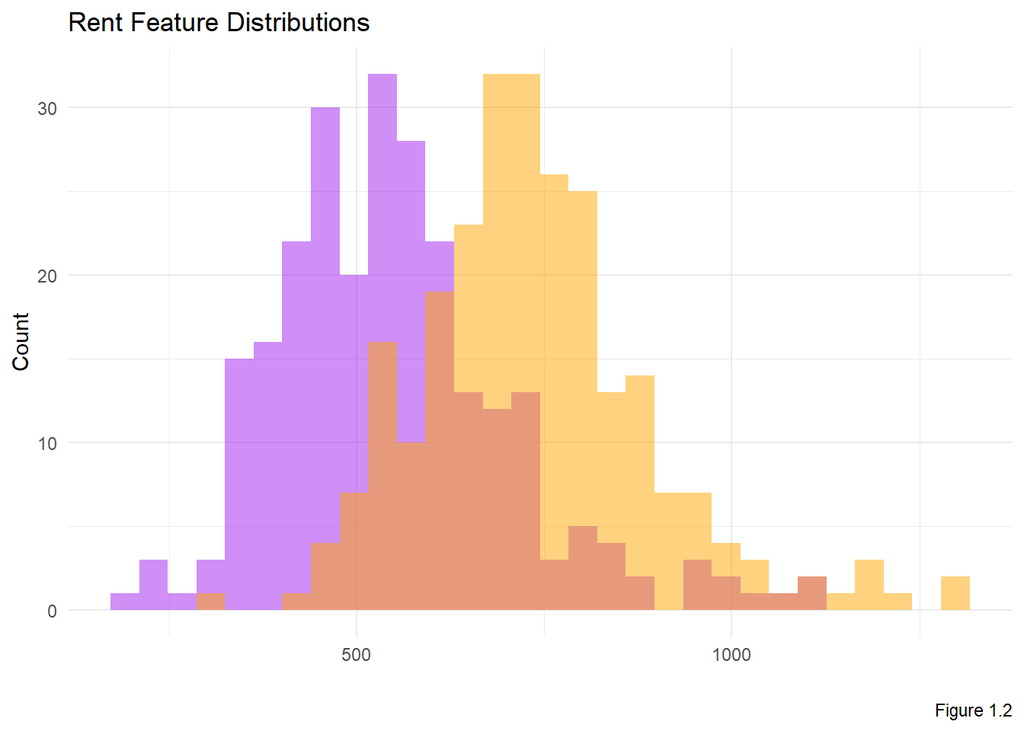

The features `median_rent` and `renter_occupied_housing_units_paying_cash_median_gross_rent` have a high positive correlation of 0.955, and their distributions (see Figure 1.2) contain significant overlap. These features are likely redundant. Since both features have nearly identical correlations to the class label, we will experiment with removing one feature or the other to assess the impact on classifier performance.

Next, we apply Principal Component Analysis (PCA) to consolidate the remaining features into components that capture variance in the dataset. PCA reduces dimensionality while retaining essential information, eliminating redundancies and ensuring effective feature representation. We evaluate the variance contribution of components using a scree plot and select components that account for 95% of the dataset’s variance.

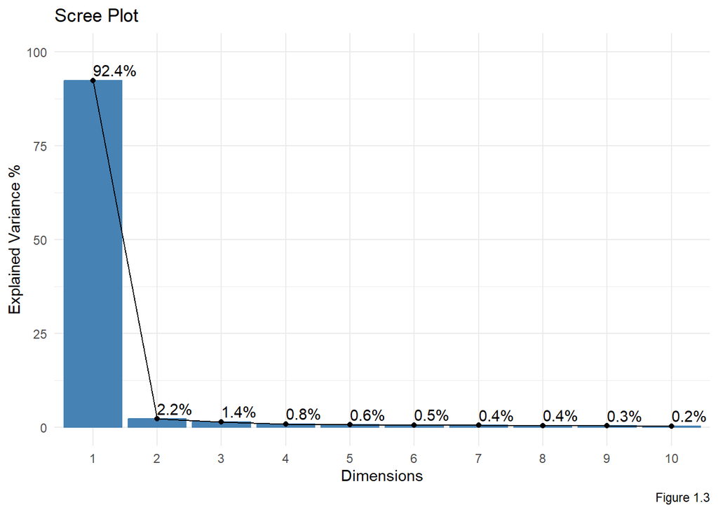

After performing PCA, the first two components explain 95% of the variance in our dataset (Figure 1.3). We evaluate how individual features contribute to these components.

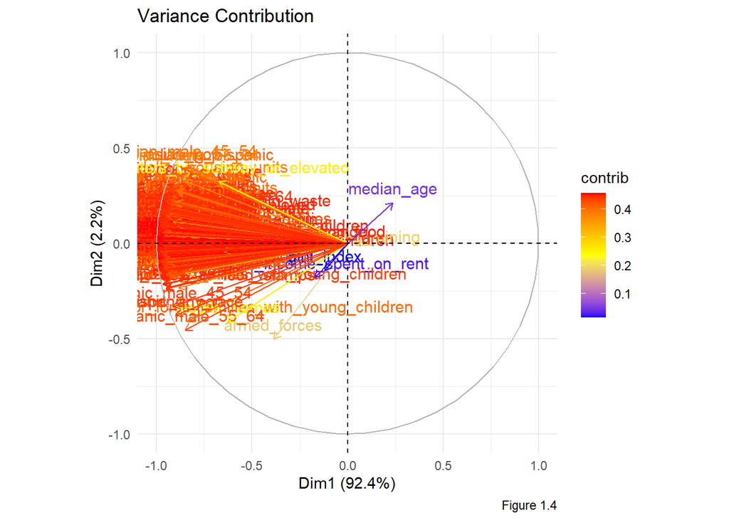

The classification models will be trained using the following features:

| Feature | Description | Requires Testing |
| --- | --- | --- |
| `confirmed_cases_per_100_000` | Confirmed cases per 100,000 people |  |
| `median_year_structure_built` | Median age of houses in a community |  |
| `pca_comp` | The first principal component in PCA |  |
| `median_income` | Median income per person | X |
| `income_per_capita` | Income per capita | X |
| `median_rent` | Median amount spent on rent | X |
| `renter_occupied_housing_units_paying_cash_median_gross_rent` | Median gross rent for people paying cash | X |

As the last stage of preprocessing, we will analyze the correlation heatmap visualization to determine every feature retained in the data model is a strong predictor.

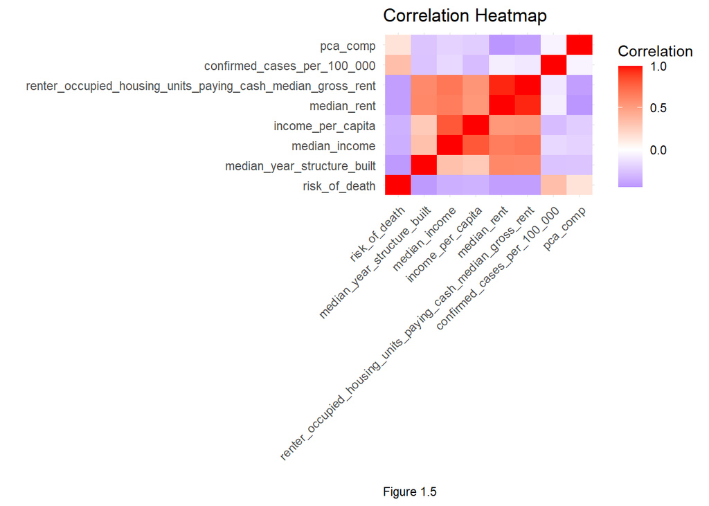

The correlation heatmap (Figure 1.5) confirms that features such as `median_income` and `income_per_capita` are strongly correlated. While both features may contribute valuable information, their redundancy will be addressed during the feature testing phase to minimize bias.

In the next section, we will evaluate the performance of each classification model with different combinations of the features marked *Requires Testing*. This approach will help identify the optimal feature set to ensure Texas policymakers receive the most accurate predictions for allocating healthcare resources.

### 1.2 Data Modeling

In this section, we will train the following classification models using the feature set described in the previous section:

1. Logistic Regression
2. Support Vector Machines
3. Artificial Neural Network (ANN)

We will begin by splitting the dataset into two separate sets: a training set, containing 80% of the 254 records in our dataset, and a test set containing the remaining 20%.

The models will be trained using the training dataset. The training dataset will be scaled independently of the test set, and PCA components will be derived exclusively from the training data to prevent cross-contamination.

The test set will be scaled using the mean and standard deviation derived from the training set and will have PCA components computed separately using the same parameters.

Each model will be evaluated using the F1 score. The F1 score represents the quantitative predictive performance by combining precision and recall, calculated using the confusion matrix of true positives, false positives, true negatives, and false negatives. As identified in the Section 1 introduction, the cost of a false negative is extremely high and could result in avoidable, unnecessary deaths. The F1 score balances these concerns, ensuring that both false positives and false negatives are considered in the evaluation.

We will calculate the F1 score using k-fold cross validation to ensure the results are not biased to a specific training/test set split and can perform well on unseen data. This is important to ensure the models can be used effectively to safeguard populations from future pandemics.

We will evaluate the F1 score of each model using the following feature set combinations:

- All Features
- Without `median_income` or `median_rent`
- Without `income_per_capita` or `renter_occupied_housing_units_paying_cash_median_gross_rent`

This approach allows us to assess the degree of similarity and redundancy between the features discussed in the previous section. By comparing performance across these feature combinations, we can identify the feature set that most effectively expresses our model and ensures optimal predictive performance.

#### 1.2.1 Logistic Regression

Logistic regressions are one of the the most popular classification model, particularly on binary classifications problems such as this. Logistic regressions calculate the predicted class (Low Risk = 0, High Risk = 1) using a sigmoid function. They are known for their simplicity and excel at small datasets like this one.

Logistic regressions to not have many hyperparameters, so the analysis will focus on evaluating performance across the different feature set combinations.

The binomial logistic regressions yielded the following results with the different feature sets:

[output not shown]

These results suggest that the sigmoid function fit the dataset reasonably well, achieving the highest F1 score with all features included. Removing certain features, such as `income_per_capita` or `renter_occupied_housing_units_paying_cash_median_gross_rent`, led to a noticeable drop in performance, indicating their contribution to the model’s predictive ability. While the redundancy described by our highly correlated features did not introduce significant bias, logistic regression’s simplicity may limit its ability to capture more complex relationships within the dataset.

In the next section, we will utilize a classification model that should perform better given the dataset size and more accurately capture the complex relationships in our dataset.

#### 1.2.2 Support Vector Machines (SVM)

In this section, we will evaluate an alternative classification model called **Support Vector Machines (SVMs)**. SVMs are ideal for small datasets ($\lt 1000$ records) and excel at capturing complex feature relationships. SVMs work by finding the optimal hyperplane that separate datapoints into different classes, essentially drawing a line between the High Risk counties and their Low Risk counterparts.

SVMs use a function to construct the hyperplane line, known as the **kernel**. We will analyse two kernel functions to evaluate their performance on our feature sets:

- **Linear**: Uses the raw feature space without applying a transformation. The most common, and fastest, kernel used today.
- **Radial**: Maps the feature space into a higher-dimensional space using a Gaussian distribution. Effective for small feature spaces with non-linear relationships.

The other SVM hyperparameters depend on the type of kernel used, such as the regularization term $C$ and $\sigma$. The parameter `tuneLength` controls the number of iterations the model will be use to determine the ideal hyperparameters for the given kernel. The ideal hyperparameters are determined using accuracy, which is acceptable given the balanced class distribution. All models in this section of the analysis will be trained with a `tuneLength` value of 5.

The Support Vector Machines yielded the following results with the different feature sets:

| Kernel | Feature Set | F1 Score |
| --- | --- | --- |
| Linear | All Features | 0.72 |
| Linear | Without `median_income` or `median_rent` | 0.75 |
| Linear | Without `income_per_capita` or `renter_occupied_housing_units_paying_cash_median_gross_rent` | 0.78 |
| Radial | All Features | 0.8 |
| Radial | Without `median_income` or `median_rent` | 0.82 |
| Radial | Without `income_per_capita` or `renter_occupied_housing_units_paying_cash_median_gross_rent` | 0.78 |

As expected, the non-linear (radial) SVM performed better on the Texas dataset than the linear model. The radial kernel’s ability to map features into a higher-dimensional space allows it to capture non-linear relationships, which are likely present in this dataset. The linear model, while faster, generally performs worse on datasets with complex relationships.

The radial SVM models performed better than the Logistic Regression across all feature sets. This improvement is likely due to the SVM’s unique ability to map complex relationships effectively, even with small datasets. Interestingly, the radial SVM achieved the best F1 score after excluding the median attributes. This suggests that the SVM may have been more prone to overfitting due to the high correlation between these features and their counterparts.

The ideal hyperparameters determined by the `tuneLength` function were:

- C: 1
- $\sigma$ (sigma): 0.337412

This indicates that the model employed moderate regularization ($C = 1$) to balance the trade-off between generalization error and overfitting. The relatively low $\sigma$ value suggests the model placed greater emphasis on individual data points rather than broader clusters in the high-dimensional feature space, likely due to the small size of the dataset.

In the next section, we will explore an unsupervised approach to classify the Texas dataset, leveraging inherent patterns without relying on predefined labels.

#### 1.2.3 Artificial Neural Network (ANN)

In this section, we will analyze the predictive ability of an unsupervised learning technique called Artificial Neural Networks (ANNs). ANNs are commonly used in a variety of machine learning applications and excel at mapping complex relationships.

ANNs consist of a sequence of nodes (called neurons) that contain individual weight functions, which are tuned through a process called backpropagation. The neurons are organized into layers. More layers allow the network to interpret and predict more complex patterns but require additional computing power and may overfit small datasets such as the one in this analysis.

The ANN hyperparameters consist of:

- `size`: the number of layers to include in the network
- `decay`: an L2 regularization parameter that dictates how quickly the weight functions will decrease via backpropagation

We will utilize the `tuneGrid` property to determine the optimal hyperparameters for our dataset. The `tuneGrid` property iterates through combinations of size (1, 3, 5) and decay (0, 0.1, 0.5) to identify the combination that achieved the highest accuracy.

The Artificial Neural Networks yielded the following results with the different feature sets:

| Feature Set | F1 Score |
| --- | --- |
| All Features | 0.81 |
| Without `median_income` or `median_rent` | 0.83 |
| Without `income_per_capita` or `renter_occupied_housing_units_paying_cash_median_gross_rent` | 0.78 |

The ANN performed better than both the Logistic Regression and SVM models, achieving a maximum F1 score of 0.83. This result was somewhat unexpected, as ANNs typically require much larger datasets to achieve reasonable predictive ability.

Similar to the SVM analysis, the ANN achieved the highest performance by excluding the median features (0.83 compared to the 0.82 from SVM). This suggests that these features do not add predictive value, despite their high correlation to the target class `risk_of_death`.

The ideal hyperparameters, as determined by the `tuneGrid` property were:

- **size** = 1
- **decay** = 0.5

This indicates the neural net needed a single hidden layer to map our dataset. A rapid decay of 0.5 most likely indicates the dataset did not require extensive iterations to adjust the activation function to an optimal level. Both of these parameters are reasonable given the dataset’s small size and limited complexity.

In summary, the ANN achieved the highest F1 score of 0.83 with the exclusion of features `median_income` and `median_rent`. This model is the best candidate to assist policymakers in identifying communities at greatest risk of death in the event of a future pandemic.

In the next section, we will evaluate the efficacy, and challenges, of using the model in a production environment.

### 1.3 Evaluation

In the previous section, we trained three classifiers to predict whether residents in a given Texas county are at low or high risk of death:

1. Logistic Regression
2. Support Vector Machine
3. Artificial Neural Network

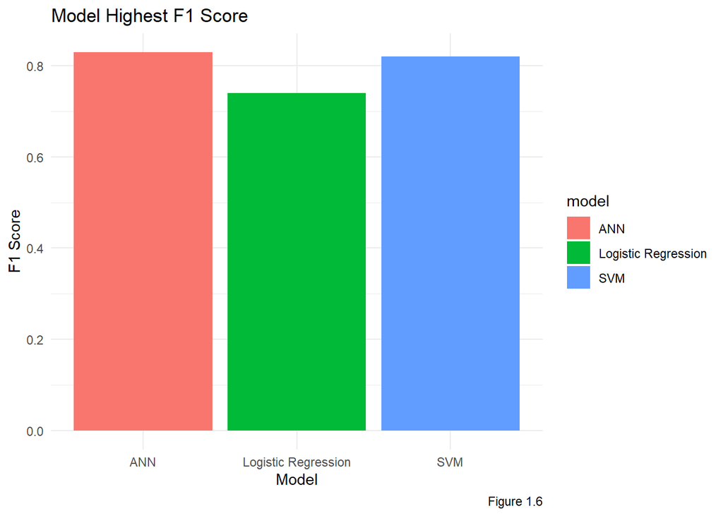

All three models achieved reasonably high F1 scores and could be used with some degree of confidence in a production environment (Figure 1.6). The Logistic Regression achieved the *lowest* predictive performance with an F1 score of 0.74, compared to the highest F1 score of 0.83 achieved by the Artificial Neural Network. None of the models were computationally expensive to train and could be retrained easily at low cost to the operator.

Of the three models, we recommend Texas policymakers utilize the ANN. The ANN achieved the highest F1 score and has the additional benefit of interoperability. The ANN model defined here could be used to predict COVID-19 related deaths, or as an input to predict risk of death for future pandemics. In contract, logistic regression and SVM may require additional analysis and training to adapt to emerging threats, potentially increasing the response time in a crisis.

Finally, policymakers should **not** rely solely on these models to allocate funding. Rather, these models should be used as an input to inform their decision. No model, including the ANN, achieved an F1 score that is high enough to replace human judgment altogether. The cost of mislabeling a county as “Low Risk” could be catastrophic to the residents in the community and lead to unnecessary death. We recommend additional research to expand the dataset by increasing the number of records (Texas counties) and incorporating more predictors.

In the next section, we will discuss how the models could be deployed to a production environment.

### 1.4 Deployment

The models would be used by Texas policymakers to allocate funding to healthcare resources more effectively. Specifically, policymakers could:

- Provide medical supplies (ex. ventilators, medical beds) to high risk counties
- Deploy additional healthcare workers to vulnerable communities

The model outputs would be presented to lawmakers and communities leaders via a dashboard on a website or in a PowerPoint presentation. High risk counties would be listed and flagged for further review. Policymakers would use these models, along with other relevant datapoints, to make funding determinations.

The models would need to be retrained and analyzed over time to ensure accuracy. Every model would need retraining after each census to incorporate the most recent demographic statistics. For the supervised algorithms, Logistic Regression and Support Vector Machines, data scientists would need to project `deaths_per_100_000` prior to retraining. The ANN could be retrained more easily due or used as an input to models designed for emerging threats.

Because the models depend on the `confirmed_cases_per_100_000` feature, data scientists could use confirmed case projections to estimate death risks. These projects could help Texas policymakers invest in preventative measures to *flatten the curve*, as described in other sections of this report.

Finally, data scientists should periodically reevaluate the feature set to identify new or emerging predictors. New information, access to vaccination or political climate statistics, could boost predictive performance and help policymakers adapt to future health challenges.

## 2. Evaluating the Effectiveness of Social Distancing

### 2.1 Data Preparation

The risk of infection was discretized into 3 categories based off the quantiles of the data. There were low risk, medium risk, and high risk categories where each group had similar numbers of samples. The classes were defined this way to ignore outlier counties and to focus on differences within the counties that were not atypical.

The 3 categories involved the number of cases per 100,000 people in the two month span from April 1 to June 1 2020. This date range was chosen because this is when social distancing was implemented everywhere in the US. Viewing the number of cases per 100,000 people during this time can help us evaluate whether counties that did less social distancing suffered more than counties that did do social distancing. All datasets were used, with predictive features coming from the census dataset and the mobility dataset. The labels were obtained from the cases dataset and dividing it by the total population in the census dataset. The features were selected to see whether social distancing played a large role in the number of cases of Covid that occurred shortly after the restrictions were put in place.

Missing data was removed from the dataset, as there was no rationale to impute data for counties that did not report their mobility data. The ranges varied wildly from county to county, so counties without the data were simply removed.

```
##
##    Low.Risk Medium.Risk   High.Risk
##          62          62          61
```

```
##         0%  33.33333%  66.66667%       100%
##    0.00000   61.99163  147.22548 3125.00000
```

Here we have divided the labels evenly among the dataset. This does create some uneven intervals of cases, with the high risk label starting as low as 147 going all the way up to 3125. However, dividing the data this way avoids a class imbalance problem, and no resampling of the data is needed. The definition of a high risk county is also subjective, and we chose to let the data itself define where the thresholds should exist.

[output not shown]

We will use the following predictors to classify Texas counties into the appropriate class labels:

[output not shown]

Higher education and multiunit_ratio were features created from combining multiple columns together.

Next, we’ll train the classification models and evaluate their accuracy.

### 2.2 Modeling

#### 2.2.1 Naive Bayes

The first model chosen is the Naive Bayes Classifier, which was initially chosen due to a significant number of missing values in the Global Mobility Data. It also was chosen because there is a limited number of data, 185 counties with no missing values. Due to the unknown nature of whether or not social distancing guidelines had any effect, a naive bayes model is robust against irrelevant features, which minimizes the effect of poorly selected features.

```
## Naive Bayes
##
## 149 samples
##  11 predictor
##   3 classes: 'Low.Risk', 'Medium.Risk', 'High.Risk'
##
## No pre-processing
## Resampling: Cross-Validated (10 fold)
## Summary of sample sizes: 134, 134, 134, 134, 134, 135, ...
## Resampling results across tuning parameters:
##
##   fL   adjust  logLoss   AUC        prAUC      Accuracy   Kappa      Mean_F1
##   0.5  1.0     3.311905  0.8215926  0.5899445  0.6566667  0.4828346  0.6714208
##   0.5  1.5     2.389649  0.8595926  0.6250873  0.6833333  0.5228346  0.6970700
##   1.0  1.0     3.543330  0.7953519  0.5597952  0.6100000  0.4128346  0.6129371
##   1.0  1.5     2.611349  0.8400926  0.5962937  0.6090476  0.4107874  0.6276310
##   2.0  1.0     3.793048  0.7667222  0.5261816  0.5628571  0.3418110  0.5633101
##   2.0  1.5     2.853691  0.8070741  0.5611381  0.5823810  0.3707874  0.5929963
##   Mean_Sensitivity  Mean_Specificity  Mean_Pos_Pred_Value  Mean_Neg_Pred_Value
##   0.6533333         0.8277778         0.7001323            0.8385580
##   0.6800000         0.8411111         0.7156746            0.8509965
##   0.6066667         0.8044444         0.6629630            0.8167937
##   0.6066667         0.8037037         0.6508201            0.8086681
##   0.5600000         0.7807407         0.6134969            0.7904334
##   0.5800000         0.7903704         0.6197090            0.7971206
##   Mean_Precision  Mean_Recall  Mean_Detection_Rate  Mean_Balanced_Accuracy
##   0.7001323       0.6533333    0.2188889            0.7405556
##   0.7156746       0.6800000    0.2277778            0.7605556
##   0.6629630       0.6066667    0.2033333            0.7055556
##   0.6508201       0.6066667    0.2030159            0.7051852
##   0.6134969       0.5600000    0.1876190            0.6703704
##   0.6197090       0.5800000    0.1941270            0.6851852
##
## Tuning parameter 'usekernel' was held constant at a value of TRUE
## logLoss was used to select the optimal model using the smallest value.
## The final values used for the model were fL = 0.5, usekernel = TRUE and
##  adjust = 1.5.
```

```
## Confusion Matrix and Statistics
##
##              Reference
## Prediction    Low.Risk Medium.Risk High.Risk
##   Low.Risk           9           3         9
##   Medium.Risk        2           8         0
##   High.Risk          1           1         3
##
## Overall Statistics
##
##                Accuracy : 0.5556
##                  95% CI : (0.381, 0.7206)
##     No Information Rate : 0.3333
##     P-Value [Acc > NIR] : 0.004991
##
##                   Kappa : 0.3333
##
##  Mcnemar's Test P-Value : 0.055044
##
## Statistics by Class:
##
##                      Class: Low.Risk Class: Medium.Risk Class: High.Risk
## Sensitivity                   0.7500             0.6667          0.25000
## Specificity                   0.5000             0.9167          0.91667
## Pos Pred Value                0.4286             0.8000          0.60000
## Neg Pred Value                0.8000             0.8462          0.70968
## Prevalence                    0.3333             0.3333          0.33333
## Detection Rate                0.2500             0.2222          0.08333
## Detection Prevalence          0.5833             0.2778          0.13889
## Balanced Accuracy             0.6250             0.7917          0.58333
```

#### 2.2.2 Random Forest

```
## Random Forest
##
## 149 samples
##  11 predictor
##   3 classes: 'Low.Risk', 'Medium.Risk', 'High.Risk'
##
## No pre-processing
## Resampling: Cross-Validated (10 fold)
## Summary of sample sizes: 134, 134, 134, 134, 134, 135, ...
## Resampling results across tuning parameters:
##
##   mtry  logLoss    AUC        prAUC      Accuracy   Kappa      Mean_F1
##    2    0.9359590  0.7722407  0.5172142  0.5766667  0.3640310  0.5718241
##    4    0.9299055  0.7783333  0.5138944  0.5976190  0.3961538  0.5933670
##    6    0.9326239  0.7706667  0.5184314  0.5704762  0.3548837  0.5654161
##    8    0.9289187  0.7735556  0.5230913  0.5776190  0.3661538  0.5750120
##   10    0.9224805  0.7728704  0.5103768  0.5909524  0.3861538  0.5878697
##   Mean_Sensitivity  Mean_Specificity  Mean_Pos_Pred_Value  Mean_Neg_Pred_Value
##   0.5750000         0.7881481         0.6001587            0.7915377
##   0.5966667         0.7988889         0.6136772            0.8028917
##   0.5683333         0.7851852         0.5875661            0.7891291
##   0.5766667         0.7888889         0.5972222            0.7926140
##   0.5900000         0.7955556         0.6136772            0.7998975
##   Mean_Precision  Mean_Recall  Mean_Detection_Rate  Mean_Balanced_Accuracy
##   0.6001587       0.5750000    0.1922222            0.6815741
##   0.6136772       0.5966667    0.1992063            0.6977778
##   0.5875661       0.5683333    0.1901587            0.6767593
##   0.5972222       0.5766667    0.1925397            0.6827778
##   0.6136772       0.5900000    0.1969841            0.6927778
##
## Kappa was used to select the optimal model using the largest value.
## The final value used for the model was mtry = 4.
```

```
## Confusion Matrix and Statistics
##
##              Reference
## Prediction    Low.Risk Medium.Risk High.Risk
##   Low.Risk           8           3         3
##   Medium.Risk        2           7         4
##   High.Risk          2           2         5
##
## Overall Statistics
##
##                Accuracy : 0.5556
##                  95% CI : (0.381, 0.7206)
##     No Information Rate : 0.3333
##     P-Value [Acc > NIR] : 0.004991
##
##                   Kappa : 0.3333
##
##  Mcnemar's Test P-Value : 0.785126
##
## Statistics by Class:
##
##                      Class: Low.Risk Class: Medium.Risk Class: High.Risk
## Sensitivity                   0.6667             0.5833           0.4167
## Specificity                   0.7500             0.7500           0.8333
## Pos Pred Value                0.5714             0.5385           0.5556
## Neg Pred Value                0.8182             0.7826           0.7407
## Prevalence                    0.3333             0.3333           0.3333
## Detection Rate                0.2222             0.1944           0.1389
## Detection Prevalence          0.3889             0.3611           0.2500
## Balanced Accuracy             0.7083             0.6667           0.6250
```

```
## rf variable importance
##
##                        Overall
## morbidity              100.000
## public_transport_ratio  64.682
## total_pop               44.973
## min_grocery             39.625
## total_dwellings         37.021
## higher_education        24.587
## multi_unit_ratio        19.248
## worked_at_home          18.656
## min_workplaces          11.604
## walked_to_work           6.824
## min_retail               0.000
```

#### 2.2.3 XGBoost

Here eXtreme Gradient Boosting is used, as it is popular ensemble method used in machine learning competitions.

```
## 'data.frame':    149 obs. of  12 variables:
##  $ min_grocery           : num  -20 -40 -25 -45 -26 -23 -17 -15 -36 -37 ...
##  $ min_retail            : num  -45 -59 -53 -60 -37 -47 -58 -55 -53 -46 ...
##  $ min_workplaces        : num  -61 -68 -63 -53 -67 -70 -56 -60 -70 -58 ...
##  $ total_pop             : num  57747 17577 87700 24832 48139 ...
##  $ walked_to_work        : num  92 0 613 281 213 253 179 159 450 259 ...
##  $ worked_at_home        : num  674 204 777 683 1165 ...
##  $ morbidity             : num  0 0 0.02 0 0.0571 ...
##  $ risk_of_infection     : Factor w/ 3 levels "Low.Risk","Medium.Risk",..: 2 3 3 1 2 2 3 1 3 1 ...
##  $ public_transport_ratio: num  0.002432 0 0.004285 0 0.000988 ...
##  $ higher_education      : num  5194 1018 9537 3560 4340 ...
##  $ total_dwellings       : num  15894 4748 28790 12250 12183 ...
##  $ multi_unit_ratio      : num  0.1167 0.0944 0.1478 0.1632 0.0784 ...
```

```
## eXtreme Gradient Boosting
##
## 149 samples
##  11 predictor
##   3 classes: 'Low.Risk', 'Medium.Risk', 'High.Risk'
##
## No pre-processing
## Resampling: Cross-Validated (10 fold)
## Summary of sample sizes: 134, 134, 134, 134, 134, 135, ...
## Resampling results across tuning parameters:
##
##   eta   max_depth  colsample_bytree  nrounds  logLoss    AUC        prAUC
##   0.01  3          0.50              100      0.9793012  0.7442222  0.4834023
##   0.01  3          0.50              200      0.9402470  0.7455556  0.4833014
##   0.01  3          0.75              100      0.9660965  0.7426667  0.4861946
##   0.01  3          0.75              200      0.9374031  0.7422222  0.4814817
##   0.01  6          0.50              100      0.9559169  0.7707778  0.5043079
##   0.01  6          0.50              200      0.9126463  0.7725741  0.5127099
##   0.01  6          0.75              100      0.9542572  0.7541667  0.4941526
##   0.01  6          0.75              200      0.9143295  0.7619815  0.5034356
##   0.10  3          0.50              100      0.9648723  0.7613519  0.5139388
##   0.10  3          0.50              200      1.0637295  0.7523704  0.4990179
##   0.10  3          0.75              100      1.0148408  0.7495370  0.4927891
##   0.10  3          0.75              200      1.1134075  0.7441111  0.4938713
##   0.10  6          0.50              100      0.9864909  0.7609630  0.5111994
##   0.10  6          0.50              200      1.0853552  0.7506296  0.5044717
##   0.10  6          0.75              100      0.9923896  0.7677963  0.5036388
##   0.10  6          0.75              200      1.0891650  0.7642963  0.5040430
##   Accuracy   Kappa      Mean_F1    Mean_Sensitivity  Mean_Specificity
##   0.5838095  0.3753846  0.5813507  0.5833333         0.7918519
##   0.5904762  0.3853846  0.5923452  0.5900000         0.7951852
##   0.5704762  0.3553846  0.5691003  0.5700000         0.7851852
##   0.5838095  0.3753846  0.5825434  0.5833333         0.7918519
##   0.5966667  0.3946154  0.5960451  0.5966667         0.7981481
##   0.6104762  0.4153846  0.6058297  0.6100000         0.8051852
##   0.5766667  0.3640310  0.5730976  0.5750000         0.7881481
##   0.5966667  0.3940310  0.5907829  0.5950000         0.7981481
##   0.5838095  0.3753846  0.5794276  0.5833333         0.7918519
##   0.5833333  0.3740310  0.5760869  0.5816667         0.7914815
##   0.5833333  0.3740310  0.5776853  0.5816667         0.7914815
```

[output cut: 34 more lines]

```
##   0.1922222            0.6815741
##   0.2011111            0.7013889
##   0.2007937            0.7003704
##   0.1966667            0.6913889
##   0.1898413            0.6763889
##
## Tuning parameter 'gamma' was held constant at a value of 0
## Tuning
##  parameter 'min_child_weight' was held constant at a value of 1
##
## Tuning parameter 'subsample' was held constant at a value of 0.75
## Kappa was used to select the optimal model using the largest value.
## The final values used for the model were nrounds = 200, max_depth = 6, eta
##  = 0.01, gamma = 0, colsample_bytree = 0.5, min_child_weight = 1 and
##  subsample = 0.75.
```

```
## Confusion Matrix and Statistics
##
##              Reference
## Prediction    Low.Risk Medium.Risk High.Risk
##   Low.Risk           8           4         4
##   Medium.Risk        1           5         4
##   High.Risk          3           3         4
##
## Overall Statistics
##
##                Accuracy : 0.4722
##                  95% CI : (0.3041, 0.6451)
##     No Information Rate : 0.3333
##     P-Value [Acc > NIR] : 0.05838
##
##                   Kappa : 0.2083
##
##  Mcnemar's Test P-Value : 0.55481
##
## Statistics by Class:
##
##                      Class: Low.Risk Class: Medium.Risk Class: High.Risk
## Sensitivity                   0.6667             0.4167           0.3333
## Specificity                   0.6667             0.7917           0.7500
## Pos Pred Value                0.5000             0.5000           0.4000
## Neg Pred Value                0.8000             0.7308           0.6923
## Prevalence                    0.3333             0.3333           0.3333
## Detection Rate                0.2222             0.1389           0.1111
## Detection Prevalence          0.4444             0.2778           0.2778
## Balanced Accuracy             0.6667             0.6042           0.5417
```

```
## xgbTree variable importance
##
##                        Overall
## morbidity               100.00
## total_pop                54.45
## public_transport_ratio   42.19
## higher_education         41.92
## total_dwellings          41.00
## min_grocery              26.95
## multi_unit_ratio         20.58
## min_workplaces           18.69
## walked_to_work           17.39
## worked_at_home           16.19
## min_retail                0.00
```

#### 2.2.4 Elastic Net

We will try next a Elastic Net model, which combines LASSO and Ridge regression and often works well with potentially correlated features like demographic data.

```
## Confusion Matrix and Statistics
##
##              Reference
## Prediction    Low.Risk Medium.Risk High.Risk
##   Low.Risk           6           6         4
##   Medium.Risk        1           4         4
##   High.Risk          5           2         4
##
## Overall Statistics
##
##                Accuracy : 0.3889
##                  95% CI : (0.2314, 0.5654)
##     No Information Rate : 0.3333
##     P-Value [Acc > NIR] : 0.2933
##
##                   Kappa : 0.0833
##
##  Mcnemar's Test P-Value : 0.2261
##
## Statistics by Class:
##
##                      Class: Low.Risk Class: Medium.Risk Class: High.Risk
## Sensitivity                   0.5000             0.3333           0.3333
## Specificity                   0.5833             0.7917           0.7083
## Pos Pred Value                0.3750             0.4444           0.3636
## Neg Pred Value                0.7000             0.7037           0.6800
## Prevalence                    0.3333             0.3333           0.3333
## Detection Rate                0.1667             0.1111           0.1111
## Detection Prevalence          0.4444             0.2500           0.3056
## Balanced Accuracy             0.5417             0.5625           0.5208
```

```
## glmnet variable importance
##
##   variables are sorted by maximum importance across the classes
##                        Low.Risk Medium.Risk High.Risk
## min_workplaces          100.000           0      0.00
## multi_unit_ratio         19.198           0     86.97
## public_transport_ratio   82.965           0      0.00
## min_grocery              55.552           0      0.00
## morbidity                 6.496           0      0.00
## walked_to_work            0.000           0      0.00
## total_pop                 0.000           0      0.00
## higher_education          0.000           0      0.00
## min_retail                0.000           0      0.00
## total_dwellings           0.000           0      0.00
## worked_at_home            0.000           0      0.00
```

The kappa here is near zero, meaning that the model has no effectiveness in predicting labels from the features.

### 2.3 Evaluation

The models generated here could be considered moderately useful for the stakeholder. They perform better than random chance, but it does show that social distancing measures may explain only a small part of the outcomes that happen in any given county. It is likely that increased social distancing often improves outcomes, but there could be numerous other factors that can negate the value of social distancing.

### 2.4 Deployment

The methods and hyperparameters here could be used to generate models in the event of another pandemic. Using the model pre-trained with only this data may not be very useful if a new disease has very different characteristics. Another concern is that the sample size of around 200 Texas counties is insufficient to generalize for the the whole US. However, if the stakeholder is of the state government, this data could be very valuable in finding relative differences in counties that experienced wildly different outcomes. In the event of another pandemic, the model should be updated frequently, and furthermore the new data should be weighted more heavily as this hypothetical new disease would have different patterns and behaviors that is not captured in these models.

## 3. Evaluating Risk of infection Based on Demographics

In the previous project, we explored whether there was a relationship between demographic groups and the infection rates of counties. Our findings indicated that counties with a higher percentage of Hispanic individuals per capita tended to have higher infection rates compared to those with less than 50% per capita. Additionally, counties with a higher percentage of White individuals per capita appeared to have lower infection rates. Based on these findings, we identified a potential connection between certain demographics and infection rates. Consequently, we decided to expand this investigation by incorporating the demographic groups used in the clustering analysis, along with additional features, to evaluate their potential in classification models for predicting a county’s risk of infection level.

### 3.1 Data Preprocessing

We will use the following predictors to classify Texas counties into the appropriate class labels:

| Feature | Description |
| --- | --- |
| `white_capita` (CREATED) | Population identifying as White divided by the total population |
| `black_capita` (CREATED) | Population identifying as Black divided by the total population |
| `asian_capita` (CREATED) | Population identifying as Asian divided by the total population |
| `hispanic_capita`(CREATED) | Population identifying as Hispanic divided by the total population |
| `unemployed_capita` (CREATED) | Population of people that are unemployed divided by the total population |
| `non_us_citizen_capita` (CREATED) | Population of non U.S citizens divided by the total population |
| `male_capita` (CREATED) | Male population divided by the total population |
| `female_capita` (CREATED) | female population divided by the total population |

The following feature will be used to form risk_of_infection class labels used for the model:

| Feature | Description |
| --- | --- |
| `confirmed_cases_per_100_000` (CREATED) | Confirmed cases per 100,000 people |

To begin, we examined the correlation between the selected features and `confirmed_cases_per_100_000`.The figure below visualizes the correlations between features.

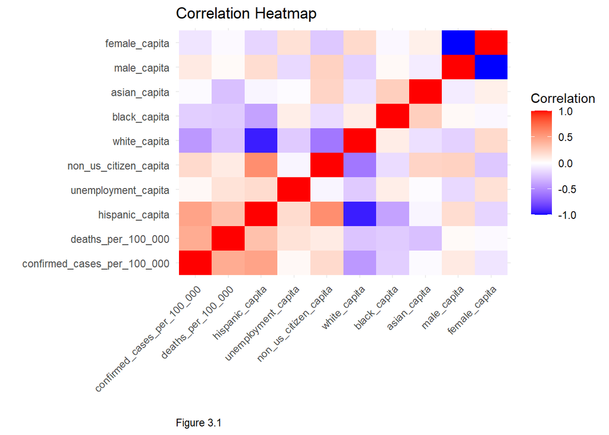

Based on Figure 3.1, it is evident that some features have a positive correlation with confirmed_cases_per_100_000, such as `hispanic_capita` and `non_us_citizen_capita`, aligning with the results of the clustering investigation. Interestingly, `male_capita` also shows a somewhat positive correlation. On the other hand, `white_capita`, `female_capita`, and `black_capita` exhibit a negative correlation with `confirmed_cases_per_100_000`. Meanwhile, `asian_capita` and `unemployment_capita` appear to have little to no correlation with `confirmed_cases_per_100_000`. Overall, several features demonstrate a clear relationship with `confirmed_cases_per_100_000`.

A class label based on `confirmed_cases_per_100_000` will be created, named risk_of_infection. This label will categorize counties into three classes: High Risk, Medium Risk, and Low Risk.

The table below displays the distribution of the three class labels. This will allow us to assess whether there is a a major class imbalance.

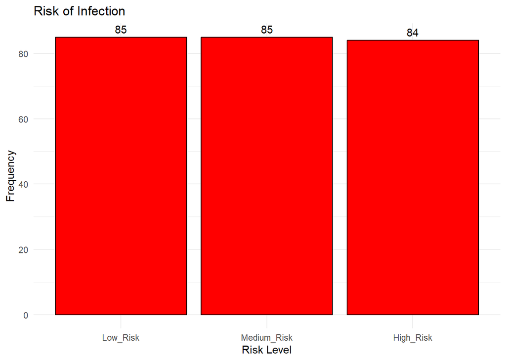

Based on values shown in figure 3.2 it is apparent that class imbalance will not be a major concern. Both the medium risk and low risk have 85 each, while high risk has 84.

## 3.2 Modeling

Now that the data has been prepared, the next step is to get it ready for modeling. The data will be split into a training set and a test set, with the training set containing 80% of the data and the test set comprising the remaining 20%.

In this modeling section, the demographic data will be fit to three different models to determine which performs best with the given data. The primary goal is to evaluate whether the demographic features of these counties can be reliably used to predict the COVID-19 risk level.

### 3.2.1 Model 1 Random Forest Classifier

The first model chosen is the Random Forest classifier, selected for its distinct advantages. First, this model can effectively handle non-linear relationships, making it well-suited for capturing the complex connections between demographic data and risk_of_infection. Second, Random Forests provide a measure of feature importance, enabling us to identify which demographic groups contribute most to the predictions and potentially revealing key insights into their connection with risk levels. Additionally, this classifier is particularly well-suited for multi-class problems like this one, as it constructs multiple trees that collectively vote on the predicted class, enhancing its overall robustness and accuracy.

For this model, hyperparameter tuning was performed using cross-validation, utilizing 7 folds to evaluate the performance of the classifier. The Hyperparameters that achieve the best performance will be used for the model itself. The one hyperparameter used by random forest is mntry, which is a parameter that specifies the number of features to randomly select and consider at each split in the decision trees that are used in this model

Cross-Validation Results for Random Forest

| mtry | Accuracy | Mean_F1 | AUC | Kappa |
| --- | --- | --- | --- | --- |
| 1 | 0.4561576 | 0.4501968 | 0.6604741 | 0.1858631 |
| 3 | 0.4464696 | 0.4327747 | 0.6589153 | 0.1728813 |
| 5 | 0.4417077 | 0.4307785 | 0.6620649 | 0.1649111 |
| 7 | 0.4466338 | 0.4634574 | 0.6622097 | 0.1720988 |
| 9 | 0.4415435 | 0.4321584 | 0.6645628 | 0.1645625 |

Best Hyperparameters for Random Forest

| mtry |
| --- |
| 1 |

### 3.2.2 Model 2- ANN

The next model utilized was an Artificial Neural Network (ANN). This model was selected for its ability to model non-linear relationships, similar to the Random Forest Classifier. Additionally, the ANN has the potential to identify interactions between demographic features, which could enhance its predictive accuracy.

To tune the hyperparameters of this model, we employed 10-fold cross-validation and tested 3 different decay parameters: 0.1, 0.01, and 0.001. The tables below showcase the performance across the folds and the selected combination of hyperparameters used for the final model. The decay paramter is meant to prevent overfitting. It is what is known as a regularization term.

| decay | Accuracy | Mean_F1 | AUC | Kappa |
| --- | --- | --- | --- | --- |
| 0.001 | 0.4980952 | 0.5010752 | 0.6420613 | 0.2463048 |
| 0.010 | 0.4802381 | 0.4674428 | 0.6300802 | 0.2217425 |
| 0.100 | 0.4457143 | 0.4572778 | 0.6319030 | 0.1707805 |

| size | decay |
| --- | --- |
| 4 | 0.001 |

Now that the hyperparameters have been found, this model is ready to be evaluated.

### 3.2.3 Model 3 - SVM

The third model selected for the demographic data was a Support Vector Machine (SVM). This model was chosen for its ability to handle non-linear relationships by utilizing kernels, which map the data to a higher-dimensional space, allowing it to capture complex patterns. Additionally, SVM excels at establishing robust decision boundaries, enabling it to make clearer and more precise classifications of the data.

The SVM has two hyperparameters that significantly impact its performance. The first is C, which controls the regularization, balancing the trade-off between achieving a low error on the training data and minimizing overfitting. The second is sigma, which serves as the kernel coefficient for the Radial Basis Function (RBF) kernel, influencing how the kernel maps data to a higher-dimensional space. To tune these hyperparameters, we used 10-fold cross-validation and tested various values for both C and sigma.

|  | C | sigma | Accuracy | Mean_F1 | AUC | Kappa |
| --- | --- | --- | --- | --- | --- | --- |
| 1 | 0.1 | 0.01 | 0.4721554 | 0.5028008 | 0.6142334 | 0.2081105 |
| 4 | 1.0 | 0.01 | 0.4266040 | 0.4329312 | 0.6535278 | 0.1388611 |
| 7 | 10.0 | 0.01 | 0.4263659 | 0.4259410 | 0.6373190 | 0.1377546 |
| 2 | 0.1 | 0.10 | 0.4809649 | 0.4685949 | 0.6366257 | 0.2222651 |
| 5 | 1.0 | 0.10 | 0.4413910 | 0.4216423 | 0.6305948 | 0.1612172 |
| 8 | 10.0 | 0.10 | 0.4336341 | 0.4548077 | 0.6365646 | 0.1486322 |
| 3 | 0.1 | 1.00 | 0.3827945 | 0.3902314 | 0.5672248 | 0.0761012 |
| 6 | 1.0 | 1.00 | 0.4031078 | 0.3951954 | 0.6001962 | 0.1023205 |
| 9 | 10.0 | 1.00 | 0.4218672 | 0.4097936 | 0.6037459 | 0.1308573 |

|  | sigma | C |
| --- | --- | --- |
| 2 | 0.1 | 0.1 |

Based on the table above, the hyperparameters that achieved the best performance are C = 0.1 and sigma = 0.1. With the best hyperparameters determined, the model is now ready for evaluation.

### 3.3. Model Evaluation

Now that all of the models have been fit,We shall evaluate the models. The metric of choice that will be used to evaluate these models will be The accuracy. The reason we selected this as the metric was due to the fact that all of the classes are balanced. Only the `High_risk` class has 1 less county than the other classes.

In addition to evaluating the accuracy, we will also examine the variable importance for two of the models: the SVM and Random Forest models. The reason we are not examining the variable importance for the ANN is that it does not inherently provide this information.Analyzing variable importance helps identify which demographic groups contributed most to the predictions and may reveal underlying patterns in the data.

The variable importance is presented in the tables below.

Variable Importance for Random Forest Model

|  | Overall |
| --- | --- |
| hispanic_capita | 93.74299 |
| unemployment_capita | 54.82059 |
| non_us_citizen_capita | 51.83572 |
| white_capita | 100.00000 |
| black_capita | 49.00572 |
| asian_capita | 0.00000 |
| male_capita | 22.15352 |
| female_capita | 18.16205 |

Variable Importance for SVM Model

|  | Low_Risk | Medium_Risk | High_Risk |
| --- | --- | --- | --- |
| hispanic_capita | 100.000000 | 56.279070 | 100.00000 |
| unemployment_capita | 15.620155 | 15.620155 | 13.25581 |
| non_us_citizen_capita | 42.558140 | 31.124031 | 42.55814 |
| white_capita | 89.069767 | 56.279070 | 89.06977 |
| black_capita | 49.883721 | 41.395349 | 49.88372 |
| asian_capita | 2.868217 | 2.868217 | 0.00000 |
| male_capita | 6.046512 | 19.147287 | 19.14729 |
| female_capita | 6.046512 | 19.147287 | 19.14729 |

Now we shall compare the accuracy each of the models. They are displayed in figure 3.3 below:

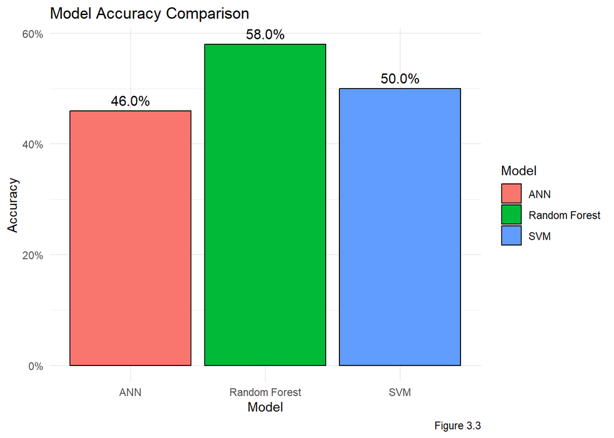

If the model were to be deployed, its value would ultimately be determined by its ability to accurately predict infection risk for new pandemic data. The goal would be for the models to provide reliable predictions that could guide action during future pandemics. However, in assessing performance, accuracy alone would not be the appropriate metric. Instead, the F1 score would be used, as it better accounts for the likely class imbalance in new data. The F1 score would provide a more comprehensive evaluation of the model’s performance, particularly in scenarios where precision and recall are critical for decision-making.

### 3.4 Deployment

In practice these models would be used to assist policymakers in deciding which counties and areas to allocate more medical resources. The idea being that if the model shows that a county is of a high or medium risk, they can prepare for that possibility by building more hospitals or sending more funding and medical supplies to the counties. The main idea behind using these models is to minimize the spread of future viruses. These models are meant to help our stakeholders focus there efforts on in-need areas so that they can handle the future pandemics more efficiently.

One thing to note is that each of these models would require consistent updates to maintain their relevance and accuracy. Specifically, they would need to be updated monthly. This is because they rely on demographic data, which can change significantly over time due to factors like population shifts or policy changes. Using updated demographic data for counties on a monthly basis would allow the models to adjust to these changes and provide more accurate predictions.

Additionally, the models would benefit from regular hyperparameter tuning during these updates. By re-tuning hyperparameters, it would be possible to optimize the models further and possibly improve their performance. By performing regular updates, the models will be able to remain consistently useful for the stakeholders and provide them with timely information about the infection risk of counties so they can react in a timely manner.

## 4. Summary

In Section 1, we trained a Logistic Regression, Support Vector Machine, and Artificial Neural Network to classify Texas counties by their `risk_of_death`. Each model was evaluated using its F1 score to balance precision and recall and reduce the number of counties mislabeled as “Low Risk”. The Artificial Neural Network achieving the highest F1 score of **0.83**. We recommend policymakers utilize the ANN to help allocate funding toward the most vulnerable communities.

## 5.0 Appendix

- Ian
  - 1. Evaluating Risk of Death
    - 1.1 Data Preprocessing
    - 1.2 Data Modeling
      - 1.2.1 Logistic Regression
      - 1.2.2 ANN (Exceptional Work)
      - 1.2.3 SVM (Exceptional Work)
    - 1.3 Evaluation
    - 1.4 Deployment
- Sanjee
  - 2. Evaluating the Effectiveness of Social Distancing
    - 2.1 Data Preparation
    - 2.2 Modeling
      - 2.2.1 Naive Bayes
      - 2.2.2 Random Forest
      - 2.2.3 XGBoost (Exceptional Work)
      - 2.2.4 Elastic Net (Exceptional Work)
    - 2.3 Evaluation
    - 2.4 Deployment
- Zach
  - 3. Evaluating Risk of infection Based on Demographics
    - 3.1 Data Preparation
    - 3.2 Modeling
      - 3.2.1 Random Forest
      - 3.2.2 Artificial Neural Network (Exceptional Work)
      - 3.2.3 Support Vector Machine (Exceptional Work)
    - 3.3 Evaluation
    - 3.4 Deployment